# Escuela de Software Libre

Marzo, 2018

## Que es Python?

Python es un lenguaje de programación interpretado, interactivo, orientado a objetos y de alto nivel. Fue creado por Guido van Rossum durante 1985-1990. Al igual que Perl, el código fuente de Python también está disponible bajo la Licencia Pública General de GNU (GPL). Python lleva el nombre de un programa de televisión llamado 'Flying Circus de Monty Python' y no de Python, la serpiente.

### Python V3

Python 3.0 se lanzó en 2008. Aunque se supone que esta versión es incompatible con versiones anteriores, posteriormente muchas de sus características importantes se han transferido para ser compatibles con la versión 2.7.

[figure not shown]

## Anaconda

Con más de 6 millones de usuarios, la distribución de código abierto Anaconda es la forma más fácil de hacer ciencia de datos de Python y aprendizaje automático. Incluye cientos de populares paquetes de ciencia de datos y el paquete conda y el administrador de entorno virtual para Windows, Linux y MacOS. Conda hace que sea fácil y rápido instalar, ejecutar y actualizar entornos complejos de ciencia de datos y aprendizaje de máquinas como Scikit-learn, TensorFlow y SciPy.

[figure not shown]

## Instalación

Anaconda en su versión Community ('Distribution'), se encuentra disponible en el siguiente link:

(https://www.anaconda.com/download/)

Existe una versión comercial ('Enterprise'), recomendada para proyectos a gran escala, acceso a Anaconda Cloud, ambiente de desarrollo colaboratibo, reproducible, escalable, seguro, y con 'Gobernancia' (control de paquetes, versiones, y acceso).

## Instalación: Paso 1

[figure not shown]

## Instalación: Paso 2

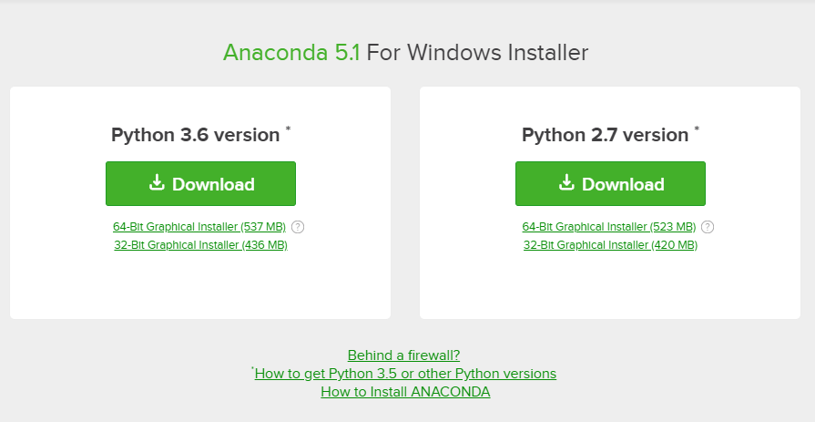

## Instalación: Paso 3

[figure not shown]

## Instalación: Paso 4

[figure not shown]

## Instalación: Paso 5

[figure not shown]

## Instalación: Paso 6

[figure not shown]

## Instalación: Paso 7

[figure not shown]

## Instalación: Paso 8

[figure not shown]

## Instalación: Paso 9

[figure not shown]

## Instalación: Paso 10

[figure not shown]

## Documentación

[figure not shown]

## Anaconda Navigator

[figure not shown]

## Spyder (Python IDE)

Spyder es un poderoso entorno de desarrollo interactivo para el lenguaje Python con funciones avanzadas de edición, pruebas interactivas, depuración e introspección. Además, Spyder es un entorno de computación numérica gracias al soporte de IPython y las populares bibliotecas de Python como NumPy (estructuras de datos), SciPy (funciones de MatLab), o matplotlib (paquetería gráfica).

[figure not shown]

## Spyder (Python IDE)

[figure not shown]

## Spyder (Python IDE)

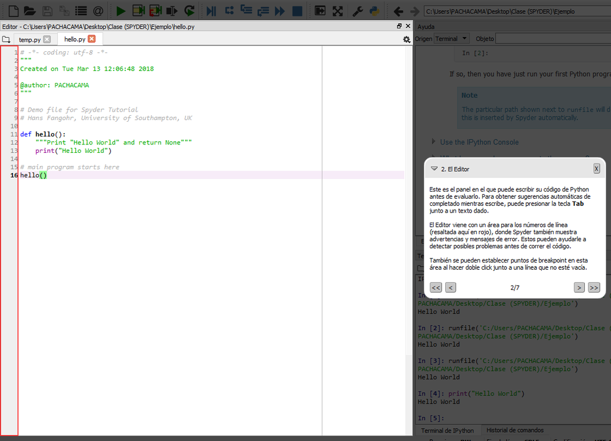

## Spyder (Python IDE)

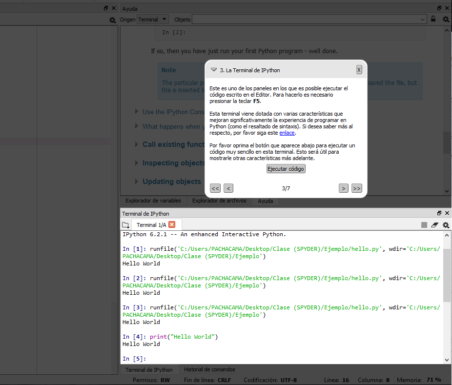